# Lowe Tweets

Josh Mark

If you’re an NBA fan, casually or a Leage Pass enthusiast, you’ve likely heard of Zach Lowe. Whether it’s his transcendent podcast, The Lowe Post [link], or appearances on The Jump [link], his basketball knowledge is boundless. He may not break news at the level of Woj, but provides maximum levels of spice to keep us all entertained and in-the-know about the sport.

So when someone is interesting to you, what do we do in 2019? We look through their tweets. Now before you think this is the tweet-searching for fireable tweets, that’s not what this is. We’re going to do a sentiment analysis on [Zach’s twitter page](https://twitter.com/ZachLowe_NBA), and see what we can find.

First, let’s get the tweets.

```r
library(rtweet)
library(httpuv)
library(syuzhet)
library(tidyverse)
library(lubridate)
library(tidytext)

lowe_account <- lookup_users('ZachLowe_NBA')
lowe_friends <- get_friends('ZachLowe_NBA') #list of people Zach follows
lowe_friend_names <- lookup_users(lowe_friends$user_id) #info on accounts Zach follows
```

The *get_timeline()* function only allows us to get 3200 tweets at time, so we’ll look at roughly 3,000 tweets from Zach.

```r
lowe_timeline <- get_timeline('ZachLowe_NBA', n = 3200) %>% # get timeline of tweets
  mutate(tweet_id = 1:n(),
         created_at = format(created_at, tz = "America/New_York"))

## clean up tweet text
tweets <- gsub("http.*", "", lowe_timeline$text)
tweets <- gsub("https.*", "", tweets)
tweets <- gsub("#.*", "", tweets)
tweets <- gsub("@.*", "", tweets)
tweets <- gsub("[[:punct:]]", "", tweets)
tweets <- gsub("[[:digit:]]", "", tweets)
```

Covering basketball is an around-the-clock job, but is Zach’s twitter round the clock too?

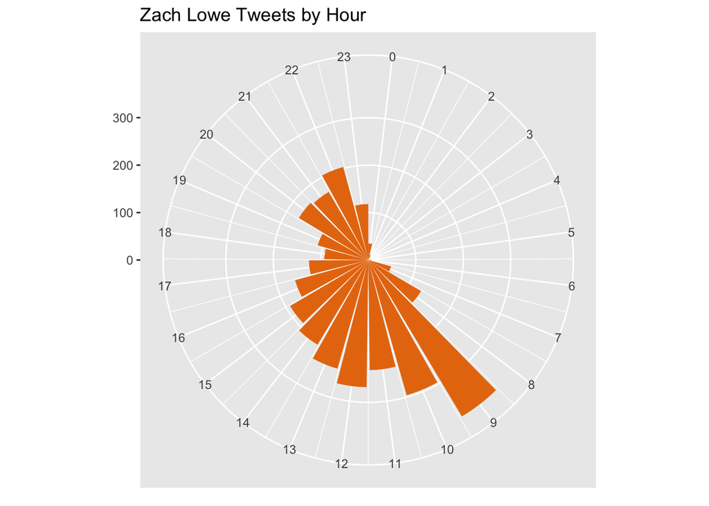

```r
lowe_timeline %>%
  mutate(tweet_hour = hour(created_at)) %>%
  count(tweet_hour) %>%
  ggplot(aes(tweet_hour, n)) +
  geom_col(fill = '#e7780f') +
  scale_x_continuous(breaks=c(0:24)) +
  coord_polar() +
  labs(y = NULL, x = NULL,
       title = 'Zach Lowe Tweets by Hour')
```

It’s good to see that Zach is getting some sleep. Rarely does he tweet between 11PM and 7AM, but his most prominent hour on Twitter is the 9AM hour.

Before doing a sentiment analysis on the tweets, we need to do some tidying.

```r
tidy_tweets <- lowe_timeline %>%
  unnest_tokens(word, text) %>%
  anti_join(stop_words, by = 'word') %>% # remove stop words
  filter(!str_detect(word, '^[0-9]'), # remove words that start with numbers
         word != 'https',
         word != 't.co') %>%
  left_join(get_sentiments("nrc"))

tidy_tweets <- tidy_tweets %>%
  left_join(get_sentiments("afinn"), by = 'word') %>%  # add sentiment score
  mutate(score = ifelse(is.na(score), 0, score))

tidy_tweets <- get_sentiments("bing") %>%
  rename(sent_value = sentiment) %>% # add positive or negative sentiment column
  right_join(tidy_tweets)
```

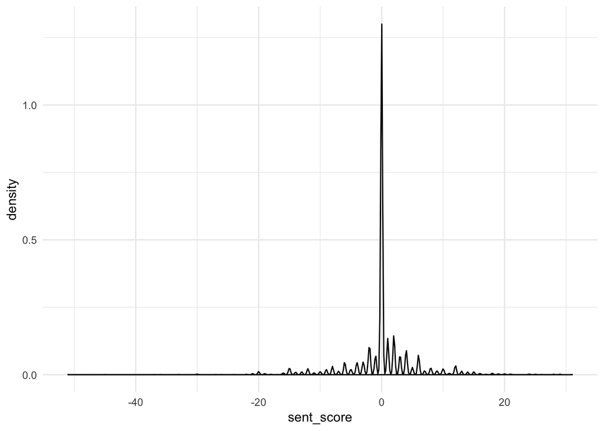

```r
tweet_sentiments <- tidy_tweets %>%
  group_by(tweet_id) %>%
  summarise(sent_score = sum(score))

ggplot(tweet_sentiments) +
  geom_density(aes(x=sent_score)) +
  theme_minimal()
```

Zach’s most positive tweet?

```r
most_positive <- tweet_sentiments[which.max(tweet_sentiments$sent_score), "tweet_id"] %>% as.integer()
knitr::kable(lowe_timeline %>%
               filter(tweet_id == most_positive) %>%
               select(created_at, text) %>% data.frame())
```

| created_at | text |
| --- | --- |
| 2018-10-23 22:10:42 | 50-14-6 on 20/35, 5/10 from deep, game-winning And-One with 1.8 left in OT, just one turnover. Played smart and solid defense all game. What a night for Blake Griffin. |

What about his most negative?

```r
most_negative <- tweet_sentiments[which.min(tweet_sentiments$sent_score), "tweet_id"] %>% as.integer()
knitr::kable(lowe_timeline %>%
               filter(tweet_id == most_negative) %>%
               select(created_at, text) %>% data.frame())
```

| created_at | text |
| --- | --- |
| 2018-04-15 18:32:35 | What a statement from the Pacers. We all assumed any bad CLE loss would stem from terrible defense. I didn’t think their D was good, but they scored 84 points per 100 possessions. Would be surprised i… |

What words does Zach use most?

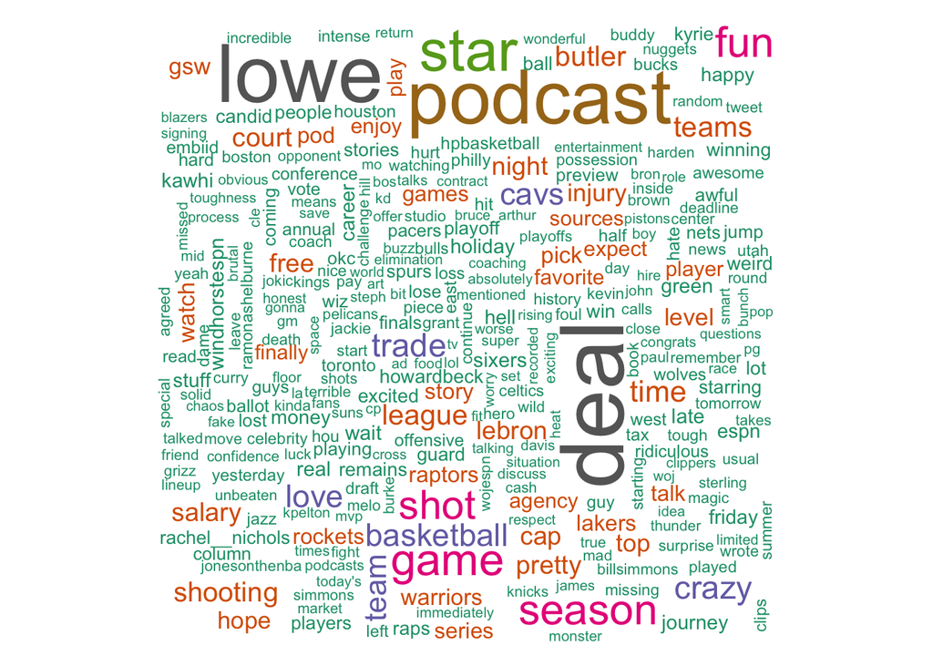

```r
set.seed(1)
library(wordcloud)
wc <- tidy_tweets %>%
  count(word, sort = T)
wordcloud(words = wc$word, freq = wc$n, min.freq = 20,
          colors = brewer.pal(12, "Dark2"))
```